# Bayes Regression Analysis

2026-05-26

# Байесовский регрессионный анализ

```r
library(tidyverse)
library(arm) # for the invlogit function
library(brms)
library(tidybayes)
library(bayestestR)

library(broom) # for tidy model summaries
library(modelr) # for the example using data_grid
data_grid <- modelr::data_grid

library(hexbin)

library(tidybayes)

library(languageR) # for `english' dataset

set.seed(100)
theme_set(theme_minimal())
```

## Классификация прайоров

Вначале немного терминологии. Выбор априорных распределений — одна из самых сложных задач при построении байесовских моделей, и поначалу совершенно новая по сравнению с частотными моделями.

Априорные распределения различаются по своей **информативности**: сколько информации о вероятных значениях параметра $\beta$ («априорные знания») они привносят в модель. Они располагаются в некотором континууме от менее информативных до более информативных:

- **Неинформативные**
  - **Плоские/неинформативные**: например, равномерное распределение на всей прямой (−∞,∞). Часто они являются несобственными (то есть такие, у которых интеграл по всему пространству не равен 1, а стремится к бесконечности). Можно сказать, что на самом деле они не являются вероятностными распределениями.
  - **неопределенные** но **собственные**: максимально плоские, но при этом остающиеся вероятностными распределениями, например, $\beta \sim N(0, 100 000)$ (примеры будут ниже)
- **Слабо информативные**
  - кодируют некоторую информацию о возможных наборах данных, но слабо
- **Информативное** / **Субъективное**
  - Содержит много априорных знаний из предыдущих работ или теории.
  - Пример: $\beta \sim N(3.2, 5)$, где 3.2 и 5 взяты из метаанализа существующих исследований.

## Данные

```r
english %>% head()
```

```
##   RTlexdec RTnaming Familiarity   Word AgeSubject WordCategory WrittenFrequency
## 1 6.543754 6.145044        2.37    doe      young            N         3.912023
## 2 6.397596 6.246882        4.43  whore      young            N         4.521789
## 3 6.304942 6.143756        5.60 stress      young            N         6.505784
## 4 6.424221 6.131878        3.87   pork      young            N         5.017280
## 5 6.450597 6.198479        3.93   plug      young            N         4.890349
## 6 6.531970 6.167726        3.27   prop      young            N         4.770685
##   WrittenSpokenFrequencyRatio FamilySize DerivationalEntropy
## 1                   1.0216512   1.386294             0.14144
## 2                   0.3504830   1.386294             0.42706
## 3                   2.0893560   1.609438             0.06197
## 4                  -0.5263339   1.945910             0.43035
## 5                  -1.0445451   2.197225             0.35920
## 6                   0.9248014   1.386294             0.06268
##   InflectionalEntropy NumberSimplexSynsets NumberComplexSynsets LengthInLetters
```

[output cut: 34 more lines]

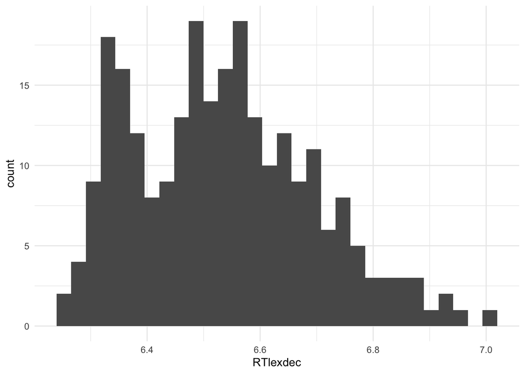

```r
english_250 <- english[sample(1:nrow(english), 250), ]
ggplot(aes(x=RTlexdec), data=english_250) +
  geom_histogram(bins = 30)
```

Построим обычную фреквентистскую линейную регрессию с `WrittenFrequency` в качестве предиктора:

```r
english_m41_freq <- lm(RTlexdec ~ 1 + WrittenFrequency, data = english_250)
# or just english_m41_freq <- lm(RTlexdec ~ WrittenFrequency, data = english_250)
summary(english_m41_freq)
```

```
##
## Call:
## lm(formula = RTlexdec ~ 1 + WrittenFrequency, data = english_250)
##
## Residuals:
##      Min       1Q   Median       3Q      Max
## -0.28506 -0.12526 -0.01311  0.11446  0.37558
##
## Coefficients:
##                   Estimate Std. Error t value Pr(>|t|)
## (Intercept)       6.720398   0.025905 259.420  < 2e-16 ***
## WrittenFrequency -0.035746   0.004674  -7.648 4.49e-13 ***
## ---
## Signif. codes:  0 '***' 0.001 '**' 0.01 '*' 0.05 '.' 0.1 ' ' 1
##
## Residual standard error: 0.1443 on 248 degrees of freedom
## Multiple R-squared:  0.1908, Adjusted R-squared:  0.1876
## F-statistic: 58.49 on 1 and 248 DF,  p-value: 4.492e-13
```

```r
tidy(english_m41_freq, conf.int = TRUE)
```

```
## # A tibble: 2 × 7
##   term             estimate std.error statistic   p.value conf.low conf.high
##   <chr>               <dbl>     <dbl>     <dbl>     <dbl>    <dbl>     <dbl>
## 1 (Intercept)        6.72     0.0259     259.   5.57e-304   6.67      6.77
## 2 WrittenFrequency  -0.0357   0.00467     -7.65 4.49e- 13  -0.0450   -0.0265
```

В нашей нотации фреквентистская модель может быть записана следующим образом:
$$y_i \sim N(\mu, \sigma)$$
$$\mu = \alpha + \beta_1
{x_1}_i$$
,

где ${x_1}_i$ – значение WrittenFrequency для наблюдения *i* (i = 1, …, n).

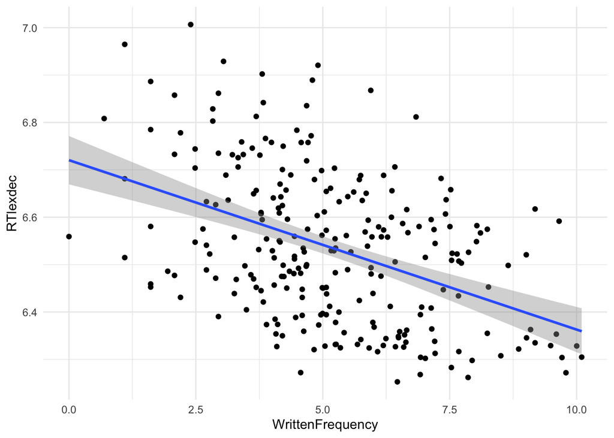

```r
english_250 %>% ggplot(aes(x = WrittenFrequency, y = RTlexdec)) +
  geom_point() +
  geom_smooth(method = "lm")
```

Построим байесовскую модель с одним интерцептом.

Мы будем использовать два параметра:  
* $\alpha$: “intercept”  
* $\sigma$: “residual variance”

Каждое наблюдение $y_i$ будет предсказываться как некоторое (среднее) значение, к которому добавляется нормально распределенный шум.

Чтобы записать вероятностную модель для данного случая, мы будем использовать прайор для $\alpha$ и $\sigma$. Имеет смысл задать для $\alpha$ «неинформативный» прайор, что, однако, требует наличия некоторой информации о вероятных значениях *y*. Еще раз взглянем на его наблюдаемое распределение:

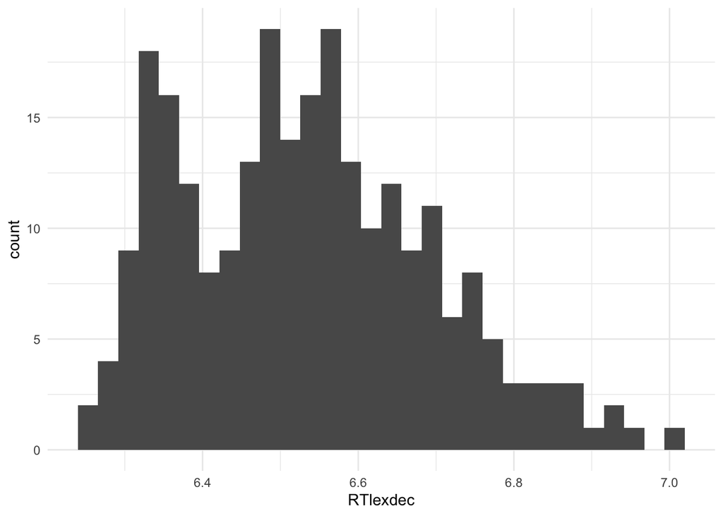

```r
ggplot(aes(x=RTlexdec), data=english_250) +
  geom_histogram(bins = 30)
```

Обратим внимание на разброс значений по оси абсцисс (`RTlexdec`). Кажется, $\alpha \sim N(0, 100)$ был бы неинформативным прайором. (Распределение практически плоское на возможных значениях $\alpha$, скажем, от -10 до 10, что соответствует времени реакции от 0,00005 до 22026 секунд!).

Каким должен быть прайор для $\sigma$? Оно должно удовлетворять двум условиям:

- Допускать только положительные значения $\sigma$ ($\sigma$ > 0)
- Распределение не должно быть плоским; по мере возрастания $\sigma$ его плотность должна убывать.

Можно было бы взять $\sigma \sim Uniform(0, 10)$ (число 10 можно заменить на любое достаточно большое значение, соответствующее масштабу *y*). Для текущих целей этот подход вполне подходит, однако в более реалистичных моделях ни равномерное, ни нормальное распределение не будет удачным выбором для параметров дисперсии. Нормальное распределение имеет «легкие хвосты» — плотность вероятности убывает слишком быстро по мере роста $\sigma$, что делает процесс MCMC-сэмплирования неэффективным.

Лучше использовать вместо этого распределение с «тяжелыми хвостами», которое по мере увеличения $\sigma$ убывало бы медленнее. Наиболее часто используют распределение «полу-Коши» (half-Cauchi), альтернатива – экспоненциальное распределение с большим параметром scale (см. McElreath 2020, гл. 9).

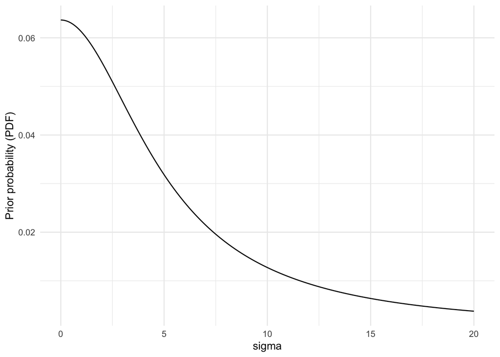

```r
data.frame(sig=seq(0, 20, by=0.1)) %>%
  mutate(prob=dcauchy(sig, scale = 5)) %>%
  ggplot(aes(x=sig, y=prob)) +
  geom_line() +
  ylab("Prior probability (PDF)") +
  xlab("sigma") -> p1
p1
```

Это распределение постепенно уменьшается от 0, образуя «длинный хвост»: более высокие значения $\sigma$ становятся все менее вероятными, но все еще имеют достаточную вероятность, чтобы модель их выучила, если для этого есть достаточно данных. Масштаб (scale) здесь выбран таким образом, чтобы прайор фактически являлся плоским для возможных значений $\sigma$: значения `RTlexdec` всегда находятся в диапазоне 6–7, поэтому $\sigma$ определенно не больше, чем примерно 1–2. (А вот если бы наши *y* варьировались от 0 до 100, нам потребовалось бы выбрать гораздо больший параметр масштаба для $\sigma$, чтобы сделать прайор «неинформативным».)

Вероятностная модель для *y* (RTlexdec) имеет следующий вид:
$$y \sim N(\mu, \sigma)$$
$$\mu \sim N(0, 100$$
$$\sigma \sim HalfCauchi(0, 5)$$

### Базовая байесовская модель

Построим модель с помощью пакета `brms` для интерцепта:

```r
english_m31 <-
  brm(data = english_250,
      RTlexdec ~ 1,
      family = gaussian,
      prior = c(prior(normal(0, 100), class=Intercept),
                prior(cauchy(0, 5), class = sigma)
      ),
      file='models/english_m31.brm'
  )
```

(Обратите внимание, что теперь prior задается как вектор, поскольку у нас несколько прайоров).

Посмотрим на результат. Модель выдает постериоры как для параметра $\mu$, так и для параметра $\sigma$ (residual variance).

```r
english_m31
```

```
##  Family: gaussian
##   Links: mu = identity
## Formula: RTlexdec ~ 1
##    Data: english_250 (Number of observations: 250)
##   Draws: 4 chains, each with iter = 2000; warmup = 1000; thin = 1;
##          total post-warmup draws = 4000
##
## Regression Coefficients:
##           Estimate Est.Error l-95% CI u-95% CI Rhat Bulk_ESS Tail_ESS
## Intercept     6.53      0.01     6.51     6.55 1.00     3306     2428
##
## Further Distributional Parameters:
##       Estimate Est.Error l-95% CI u-95% CI Rhat Bulk_ESS Tail_ESS
## sigma     0.15      0.01     0.13     0.16 1.00     2561     2512
##
## Draws were sampled using sampling(NUTS). For each parameter, Bulk_ESS
## and Tail_ESS are effective sample size measures, and Rhat is the potential
## scale reduction factor on split chains (at convergence, Rhat = 1).
```

Сравним выдачу модели с фреквентистской моделью `lm(RTlexdec ~ 1)`: там выдаются только оценки для $\mu$ (SE, p-value…).

```r
summary(lm(RTlexdec ~ 1, data=english))
```

```
##
## Call:
## lm(formula = RTlexdec ~ 1, data = english)
##
## Residuals:
##      Min       1Q   Median       3Q      Max
## -0.34477 -0.12457  0.00037  0.10311  0.63771
##
## Coefficients:
##             Estimate Std. Error t value Pr(>|t|)
## (Intercept) 6.550097   0.002322    2821   <2e-16 ***
## ---
## Signif. codes:  0 '***' 0.001 '**' 0.01 '*' 0.05 '.' 0.1 ' ' 1
##
## Residual standard error: 0.1569 on 4567 degrees of freedom
```

В выдаче байесовской модели $\mu$ выдается как first-class параметр (Regression Coefficients), а $\sigma$ (residual variance) как Further Distributional Parameters.

### Метрики качества модели: R-hat, Bulk_ESS и Tail_ESS

R-hat ($\widehat{R}$) -– это диагностика сходимости, которая сравнивает оценку модели, которая получается внутри цепи и между цепями (введена в Gelman and Rubin (1992). Если цепи не перемешались (например, если нет согласия внутри цепи и между цепями), R-hat будет иметь значение больше 1. Собственно для этого рекоммендуется запускать по крайней мере 4 цепи. (В библиотеке Stan есть более сложные методы, о которых можно узнать [здесь](https://statmodeling.stat.columbia.edu/2019/03/19/maybe-its-time-to-let-the-old-ways-die-or-we-broke-r-hat-so-now-we-have-to-fix-it/).

|| $\widehat{R} \leq 1.05$ – значит проблем со сходмиостью цепей не обнаружено.

Bulk ESS (Effective sample size) — это оценка качества сэмплирования в середине апостериорного распределения, а Tail ESS — в краях апостериорного распределения. Чем выше ESS – тем лучше.

### Исследуем апостериорное распределение

Итак, мы можем исследовать апостериорное распределение $\sigma$. (Могли бы сразу для $\mu$ и $\sigma$, но сейчас это не обязательно).

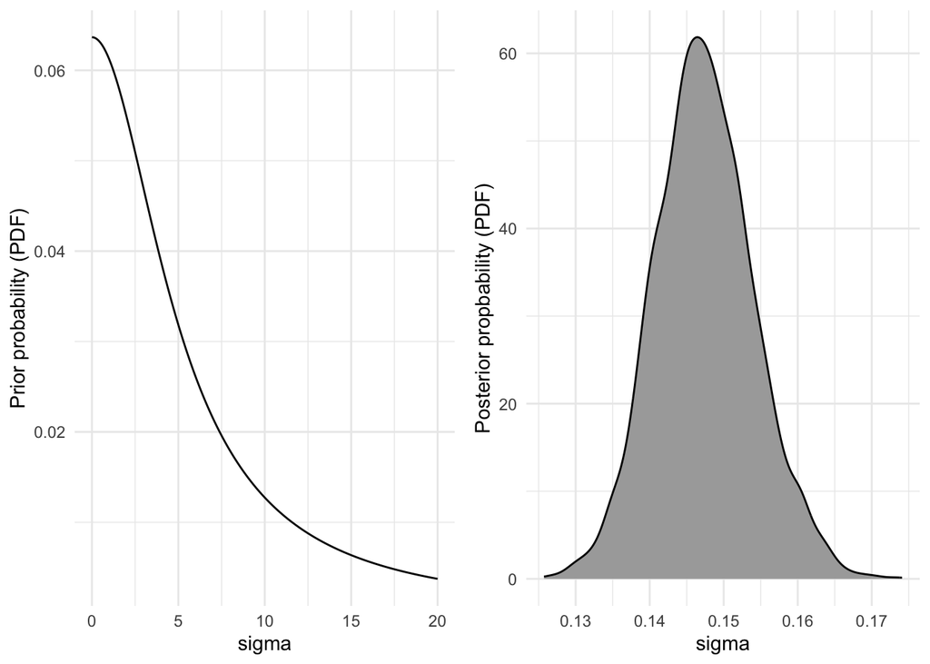

```r
p2 <- english_m31 %>%
  spread_draws(sigma) %>%
  ggplot(aes(x = sigma)) +
  geom_density(fill = "darkgrey") +
   ylab("Posterior propbability (PDF)")

## compare to the prior
library(gridExtra)
grid.arrange(p1, p2, ncol = 2)
```

### Имена параметров модели

Начав работать с более чем одним параметром, давайте ознакомимся с еще несколькими возможностями `brms`.

Для извлечения выборок нам потребуются имена параметров, которые могут быть не вполне очевидны из вывода `brms`. Вы всегда можете просмотреть все параметры модели с помощью функции `get_variables()`:

```r
get_variables(english_m31)
```

```
##  [1] "b_Intercept"   "sigma"         "Intercept"     "lprior"
##  [5] "lp__"          "accept_stat__" "stepsize__"    "treedepth__"
##  [9] "n_leapfrog__"  "divergent__"   "energy__"
```

Все, что оканчивается на __, представляет собой внутренние параметры алгоритма MCMC, которые мы, как правило, игнорируем.

## Диагностика модели: первый взгляд

При подгонке моделей `brms/Stan` важно проанализировать выборки из апостериорного распределения, чтобы убедиться, что цепи должным образом «смешиваются» и что мы действительно получили качественную выборку из апостериорного распределения. Это важное отличие от фреквентистских моделей, алгоритм подгонки которых, как правило, выдает осмысленный результат при использовании настроек по умолчанию — независимо от того, какие данные вы ему подаете (в разумных пределах).

Функция `plot()` отображает базовые диагностические данные: апостериорные распределения и трассировочные графики (trace plots, известные также как мохнатая гусеница) для каждого параметра:

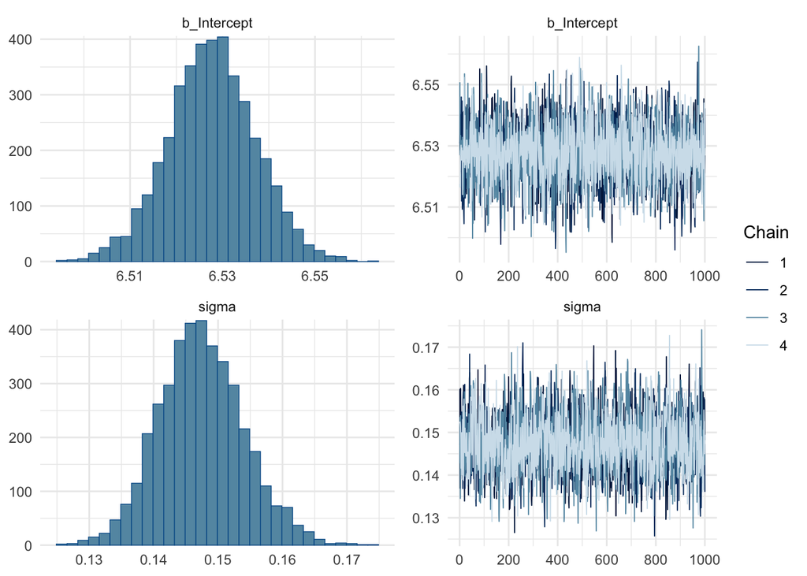

```r
plot(english_m31)
```

Графики траекторий выглядят хорошо: они напоминают «волосатую гусеницу», причём ни одна из цепочек визуально не отличается от остальных (цепи хорошо накладываются друг на друга). Эта визуальная диагностика служит важной базовой проверкой на адекватность для любой модели, построенной с использованием MCMC-методов — даже для самых простых.

## 2D тепловая карта для двух постериоров

Извлечем сразу два постериора $\mu$ и $\sigma$ из `english_m31` в один датафрейм с помощью `spread_draws()`.

```r
english_m31_draws <- english_m31 %>% spread_draws(b_Intercept, sigma)
english_m31_draws
```

```
## # A tibble: 4,000 × 5
##    .chain .iteration .draw b_Intercept sigma
##     <int>      <int> <int>       <dbl> <dbl>
##  1      1          1     1        6.53 0.160
##  2      1          2     2        6.53 0.137
##  3      1          3     3        6.53 0.137
##  4      1          4     4        6.53 0.160
##  5      1          5     5        6.52 0.155
##  6      1          6     6        6.53 0.142
##  7      1          7     7        6.53 0.149
##  8      1          8     8        6.52 0.149
##  9      1          9     9        6.52 0.149
## 10      1         10    10        6.52 0.151
## # ℹ 3,990 more rows
```

Построим 2D тепловую карту, которая будет показывать постериоры (x-axis = $\alpha$, y-axis = $sigma$, color=probability density) с помощью `geom_hex()`.

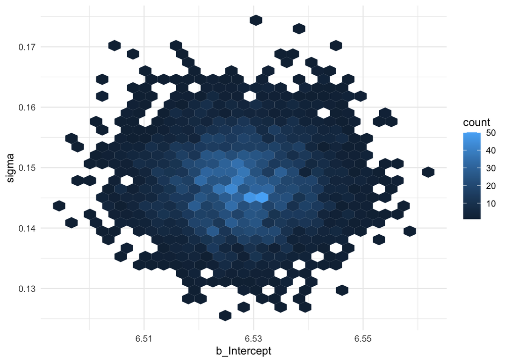

```r
english_m31_draws %>%
  ggplot(aes(x = b_Intercept, y = sigma)) +
  geom_hex() +
  xlab("b_Intercept") +
  ylab("sigma")
```

```r
## also geom_density_2d_filled(), or see (Kurz 2023, 4.3.6).
```

## Байесовская линейная регрессия с одним предиктором

### Прайор для $\sigma$

Рассмотрим пример использования прайора из [экспоненциального](https://ru.wikipedia.org/wiki/%D0%AD%D0%BA%D1%81%D0%BF%D0%BE%D0%BD%D0%B5%D0%BD%D1%86%D0%B8%D0%B0%D0%BB%D1%8C%D0%BD%D0%BE%D0%B5_%D1%80%D0%B0%D1%81%D0%BF%D1%80%D0%B5%D0%B4%D0%B5%D0%BB%D0%B5%D0%BD%D0%B8%D0%B5) распределения для $\sigma$. В отличие от полу-Коши, экспоненциальное распределение имеет единственный параметр $\lambda$ — «интенсивность» (rate), а также ожидаемое значение $1 / \lambda$; следовательно, чем меньше значение $\lambda$, тем шире распределение.

Как полу-Коши, так и экспоненциальное распределение обладают свойствами, делающими их подходящими априорными распределениями для параметров дисперсии:

- $\sigma$ ограничена положительными значениями
- «Тяжелый хвост»: возможны высокие значения $\sigma$, хотя априори они считаются маловероятными
- Семплирование из апостериорного распределения (а также из апостериорного прогностического распределения) с использованием MCMC-алгоритмов работает отлично.

Однако экспоненциальное распределение лучше подходит для реализации четвертого желаемого свойства: * семплирование из **априорного прогностического распределения** с помощью MCMC-алгоритмов.

Именно этот прайор мы будем использовать для параметра $\sigma$ в рассматриваемых далее моделях линейной регрессии: Exponential(1).

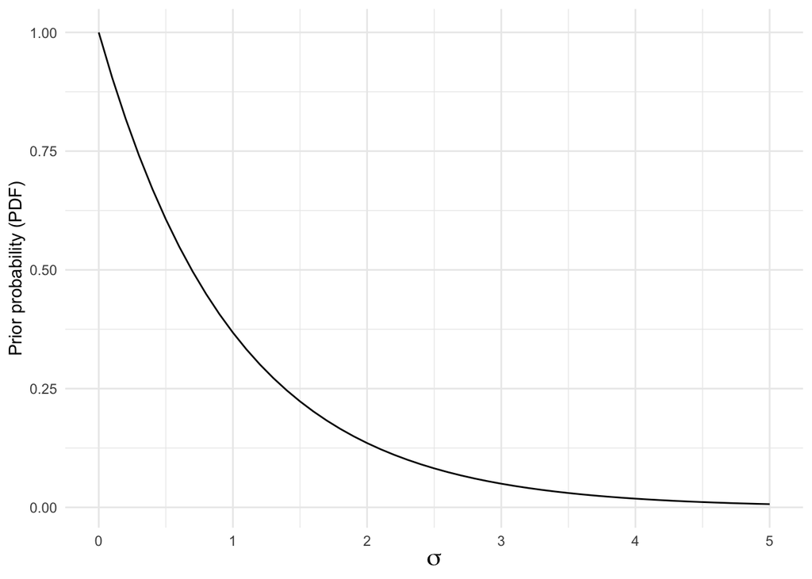

```r
data.frame(sig = seq(0, 5, by = 0.1)) %>%
  mutate(prob = dexp(sig, rate = 1)) %>%
  ggplot(aes(x = sig, y = prob)) +
  geom_line() +
  ylab("Prior probability (PDF)") +
  xlab(expression(sigma)) +
  theme(axis.title.x = element_text(size = 15))
```

Напомним, что разумные значения `RTlexdec` составляют 6–7; следовательно, значение ~1 было бы велико, а значит, это относительно хороший неинформативный прайор.

### Прайор для $\beta_1$

Дополнительная вещь, необходимая нам для построения вероятностной модели в данном случае, — это априорное распределение для $\beta_1$. Мы будем использовать $\beta_1 \sim N(0, 5)$, которое является «неинформативным» исходя из следующей логики:

- Центрирование в нуле: не дает информации о направлении эффекта.
- Для переменной `RTlexdec` изменение на 1 единицу — это очень много; для `WrittenFrequency` изменение на 10 единиц — это тоже очень много (см. диапазон значений данных), следовательно, slope, равный 1/10 = 0,1, является большим. Таким образом, $\sigma = 5$, представляет собой действительно огромную величину, если вспомнить про стандартный разброс ±3$\sigma$.

Этот график показывает, что для правдоподобных эффектов ($|\beta_1| < 0.3$) априорная вероятность имеет довольно плоскую форму:

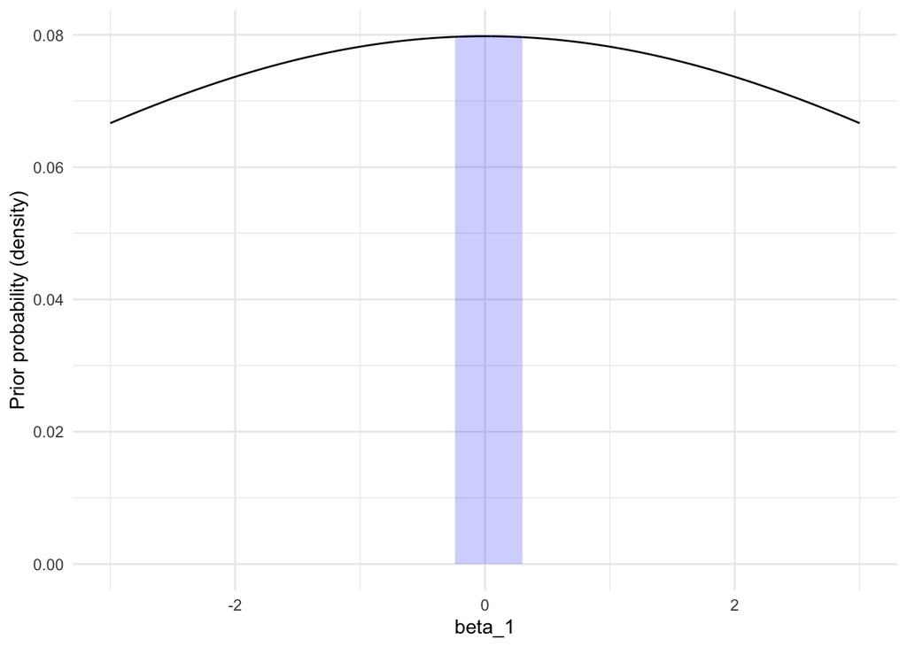

```r
dnorm_limit <- function(x) {
  y <- dnorm(x, sd = 5)
  y[x > 0.3 | x < (-0.3)] <- NA
  return(y)
}

df <- data.frame(beta1 = seq(-3, 3, by = 0.001), p = dnorm(x = seq(-3, 3, by = 0.001), sd = 5))

## log-odds of -5 to 5
df %>% ggplot(aes(x = beta1, y = p)) +
  geom_line() +
  xlab("beta_1") +
  ylab("Prior probability (density)") +
  xlim(-3, 3) +
  stat_function(fun = dnorm_limit, geom = "area", fill = "blue", alpha = 0.2)
```

(Здесь использован очень широкий прайор, поэтому оно также является плоским для эффектов `AgeSubject` и полиномов `RTlexdec`, которые мы рассмотрим ниже.)

Вероятностная модель для *y* (RTlexdec) тогда выглядит следующим образом:

$$y_i \sim N(\mu_i,\sigma)$$
$$\mu_i = \alpha +
{\beta_1x_1}_{i}$$
$$\alpha \sim N(0,100)$$
$$\beta_1 \sim N(0,5)$$
$$\sigma \sim \textrm{Exponential}(1)$$

### Модель

(Опустим здесь детали построения модели с помощью `message=FALSE`).

```r
## this uses defaults for MCMC: chains = 4, iter = 2000, warmup = 1000
english_m41 <-
  brm(
    data = english_250,
    RTlexdec ~ 1 + WrittenFrequency,
    family = gaussian,
    prior = c(
      prior(normal(0, 100), class = Intercept),
      prior(normal(0, 5), class = b),
      prior(exponential(1), class = sigma)
    ),
    file = "models/english_m41.brm"
  )
english_m41
```

```
##  Family: gaussian
##   Links: mu = identity
## Formula: RTlexdec ~ 1 + WrittenFrequency
##    Data: english_250 (Number of observations: 250)
##   Draws: 4 chains, each with iter = 2000; warmup = 1000; thin = 1;
##          total post-warmup draws = 4000
##
## Regression Coefficients:
##                  Estimate Est.Error l-95% CI u-95% CI Rhat Bulk_ESS Tail_ESS
## Intercept            6.72      0.03     6.67     6.77 1.00     4928     2815
## WrittenFrequency    -0.04      0.00    -0.04    -0.03 1.00     5031     2877
##
## Further Distributional Parameters:
##       Estimate Est.Error l-95% CI u-95% CI Rhat Bulk_ESS Tail_ESS
## sigma     0.15      0.01     0.13     0.16 1.00     3692     2761
##
## Draws were sampled using sampling(NUTS). For each parameter, Bulk_ESS
## and Tail_ESS are effective sample size measures, and Rhat is the potential
## scale reduction factor on split chains (at convergence, Rhat = 1).
```

Оценки `Intercept` и `WrittenFrequency`, основанные на апостериорных сводках, очень похожи на выдачу фреквентистской модели, описанной выше. Всегда проверяйте trace plots на наличие мохнатых гусениц и правдоподобно выглядящих апостериорных распределений.

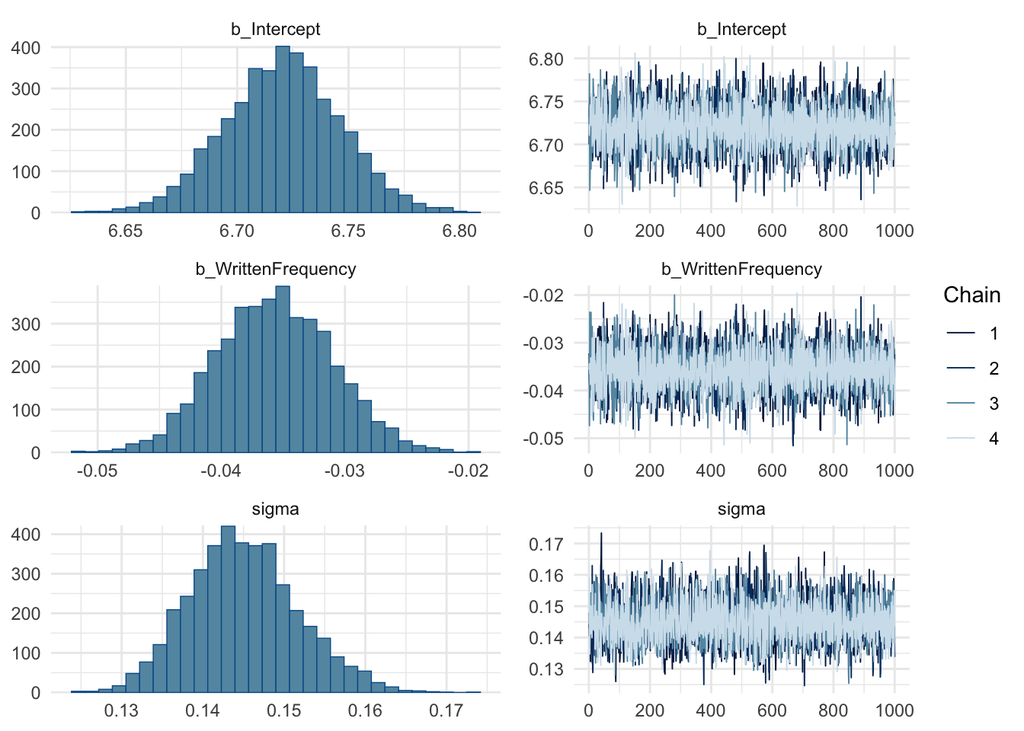

```r
plot(english_m41)
```

Чтобы получить представление о том, что предсказывает эта модель, рассмотрим 2D-тепловую карту для $\alpha$ и $\beta_1$:

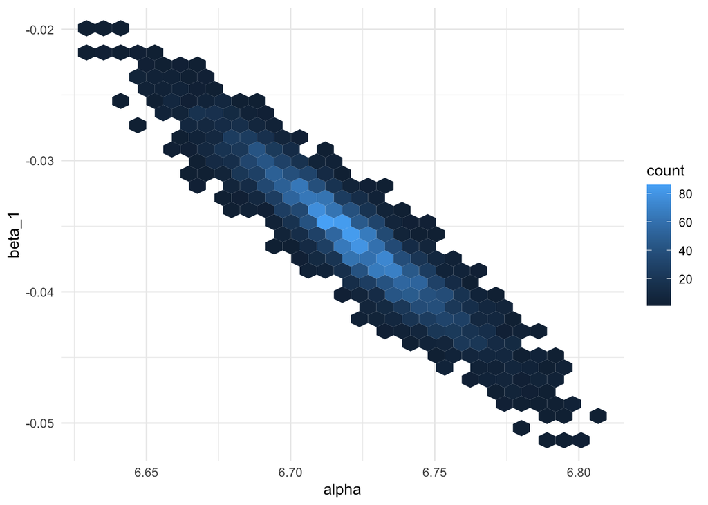

```r
english_m41 %>%
  spread_draws(b_Intercept, b_WrittenFrequency) %>%
  ggplot(aes(x = b_Intercept, y = b_WrittenFrequency)) +
  geom_hex() +
  xlab("alpha") +
  ylab("beta_1")
```

В (Kurz 2023, раздел 4.4.1) показано, как сделать это вручную. Мы же воспользуемся функционалом пакета [`tidybayes`](http://mjskay.github.io/tidybayes/articles/tidy-brms.html).

Сначала получим выборки ожидаемых значений *y* как функцию от *x*. Для этого мы используем функцию `data_grid()` из пакета `modelR`, чтобы сформировать датафрейм со значениями *x*, для которых требуется выполнить предсказание; затем мы применяем функцию `add_epred_draws()` из пакета `tidybayes`:

```r
y_draws <- english_250 %>%
  ## get grid of values on x axis
  data_grid(WrittenFrequency = seq_range(WrittenFrequency, n = 101)) %>%
  add_epred_draws(english_m41, ndraws = 100)
```

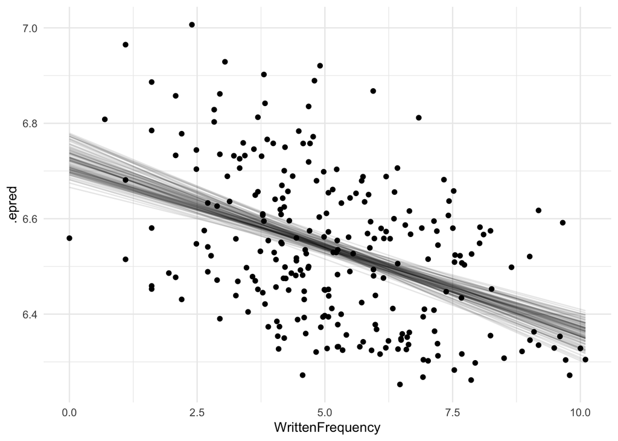

```r
y_draws %>%
  ggplot(aes(x = WrittenFrequency, y = RTlexdec)) +
  geom_line(aes(y = .epred, group = .draw), alpha = .1) +
  geom_point(data = english_250) +
  theme(legend.position = "none")
```

Неформально такой график называется «график-спагетти». Для лучшего понимания может быть полезно [анимировать этот график](https://mjskay.github.io/tidybayes/articles/tidy-brms.html#fitprediction-curves), чтобы линии отображались по одной (так называемый *график гипотетических исходов*).

## Прогнозируемые эффекты 1

Как правило, прогнозируемые эффекты модели (в данном случае — для *x*) принято визуализировать с использованием CredI («доверительного интервала», именуемого также «интервалом достоверности»). Это достигается путем отображения некоторого обобщенного прогнозируемого эффекта с учетом неопределенности (например, путем вычисления медианы и 95%-CI для всего «пучка» линий — для *y* при каждом значении *x*).

Используем возможности `tidybayes`:

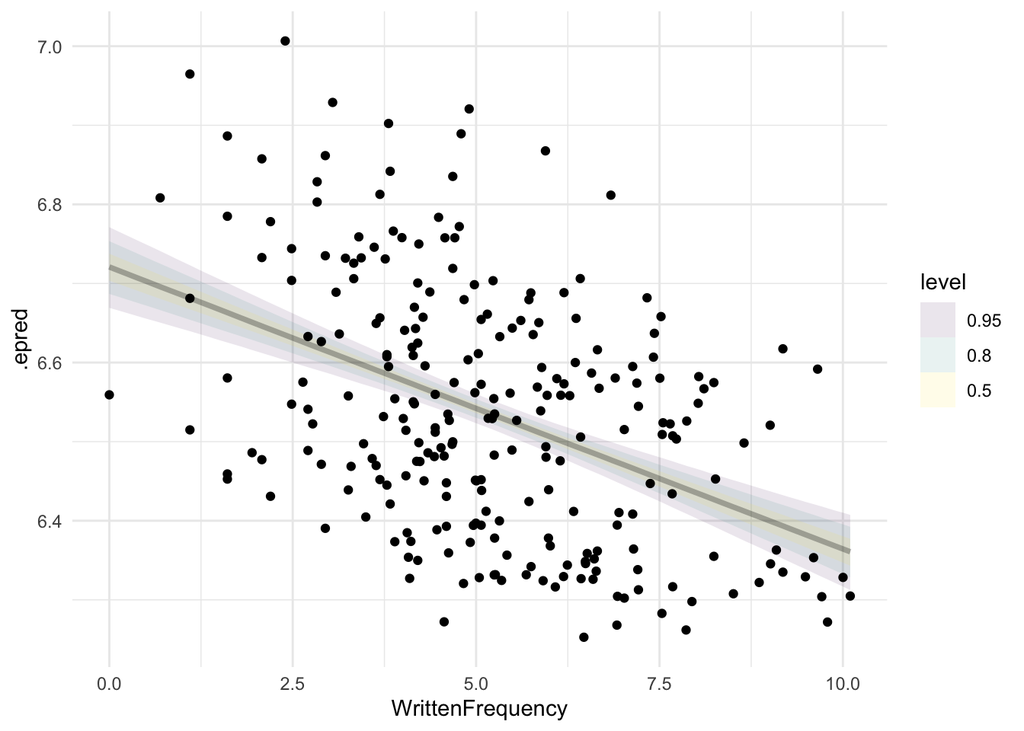

```r
english_250 %>%
  data_grid(WrittenFrequency = seq_range(WrittenFrequency, n = 101)) %>%
  add_epred_draws(english_m41) %>%
  ggplot(aes(x = WrittenFrequency, y = RTlexdec)) +
  stat_lineribbon(aes(y = .epred), alpha = 0.1) +
  geom_point(data = english_250)
```

Еще проще — просто показать 95% CredI:

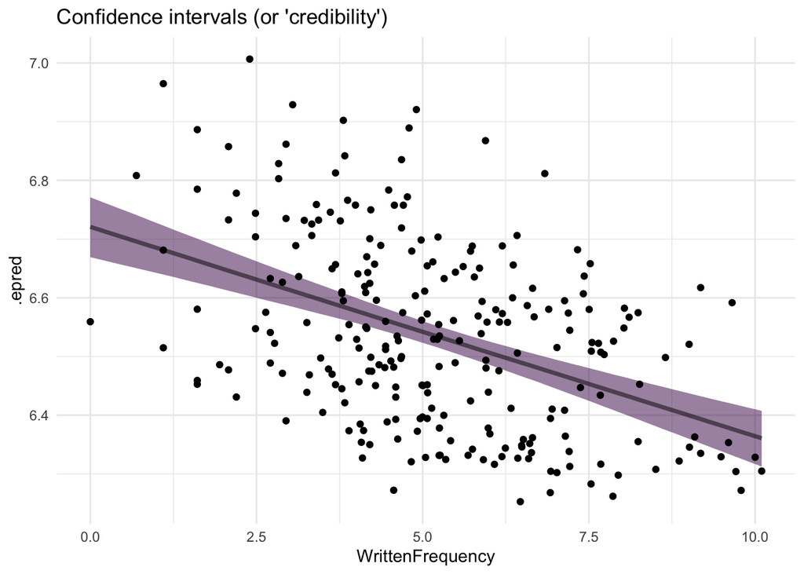

```r
## get grid of values on x axis
english_250 %>%
  data_grid(WrittenFrequency = seq_range(WrittenFrequency, n = 101)) %>%
  add_epred_draws(english_m41) %>%
  ggplot(aes(x = WrittenFrequency, y = RTlexdec)) +
  stat_lineribbon(aes(y = .epred), .width = c(0.95), alpha = 0.5) +
  geom_point(data = english_250) +
  theme(legend.position = "none") +
  ggtitle("Confidence intervals (or 'credibility')")
```

Мы можем выполнить это с помощью функции `add_predicted_draws()` из пакета `tidybayes`:

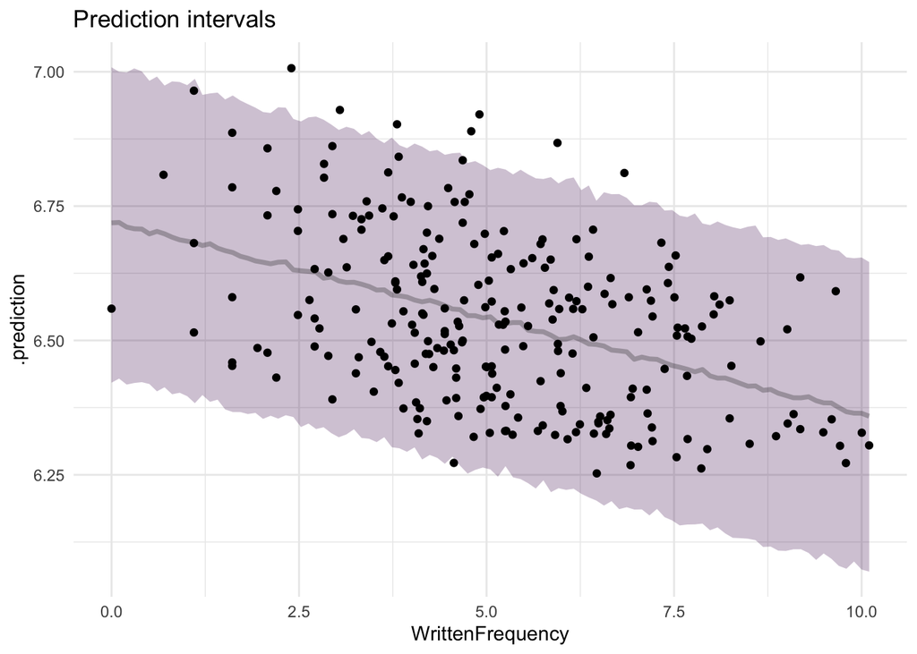

```r
## get grid of values on x axis
english_250 %>%
  data_grid(WrittenFrequency = seq_range(WrittenFrequency, n = 101)) %>%
  add_predicted_draws(english_m41) %>%
  ggplot(aes(x = WrittenFrequency, y = RTlexdec)) +
  stat_lineribbon(aes(y = .prediction), .width = c(.95), alpha = 1 / 4) +
  geom_point(data = english_250) +
  ggtitle("Prediction intervals") +
  theme(legend.position = "none")
```

Обратите внимание: 95%-ый интервал прогноза (PI) охватывает большинство наблюдений, тогда как 95%-ый CI — нет, что вполне ожидаемо.

В более общем смысле, для любых значений предикторов мы можем получить апостериорное распределение для:

- **подобранных (fitted) значений** (рассчитанных исключительно на основе предикторов);
- **предсказаний модели** (реальных значений $y_1$, учитывающих наличие шума).

Терминология в разных пакетах и у разных авторов может различаться, однако само наличие этих двух типов «прогнозов» является универсальным. В пакете `brms` они извлекаются с помощью функций `fitted()` и `predict()` соответственно. В пакетах `tidybayes` и `rstan` функции этих двух типов содержат в своих названиях подстроки `epred` и `predict` (как, например, в функциях `tidybayes`, использованных для построения графиков выше).

В качестве примера с использованием функций `brms`: среднее значение и 95%-ый CI для подобранных значений первых пяти наблюдений из `english_250` выглядят следующим образом:

```r
fitted(english_m41) %>% head(n = 5)
```

```
##      Estimate   Est.Error     Q2.5    Q97.5
## [1,] 6.584696 0.011261076 6.562630 6.607722
## [2,] 6.463164 0.013251238 6.436440 6.488517
## [3,] 6.360148 0.024800240 6.312407 6.407386
## [4,] 6.541979 0.009274494 6.523197 6.560145
## [5,] 6.591680 0.011809111 6.568264 6.615969
```

```r
##      Estimate   Est.Error     Q2.5    Q97.5
## [1,] 6.584161 0.011296955 6.562595 6.606617
## [2,] 6.462223 0.012807470 6.437004 6.487829
## [3,] 6.358862 0.023808050 6.312888 6.406904
## [4,] 6.541302 0.009289047 6.523069 6.559617
## [5,] 6.591168 0.011830462 6.568698 6.614645
```

То же для предсказаний модели:

```r
predict(english_m41) %>% head(n = 5)
```

```
##      Estimate Est.Error     Q2.5    Q97.5
## [1,] 6.583545 0.1442992 6.308435 6.869185
## [2,] 6.456768 0.1458183 6.165083 6.738629
## [3,] 6.360450 0.1482608 6.067033 6.647185
## [4,] 6.542975 0.1465690 6.254759 6.822753
## [5,] 6.590423 0.1461819 6.311043 6.875416
```

```r
##      Estimate Est.Error     Q2.5    Q97.5
## [1,] 6.586306 0.1442737 6.301712 6.872248
## [2,] 6.459703 0.1451474 6.183633 6.742939
## [3,] 6.358503 0.1453746 6.079538 6.643806
## [4,] 6.540256 0.1441920 6.254455 6.820970
## [5,] 6.590544 0.1464116 6.301902 6.870175
```

Различие здесь аналогично различию между «доверительными интервалами» и «прогнозными интервалами» в фреквентистских моделях (см. Sonderegger 2023, [разд. 8.8.2](https://github.com/msonderegger/rmld-v1.1/)).

Обратите внимание, что для фреквентистских моделей функции `fitted` и `predict` дадут один и тот же результат (если исключить подходы с добавлением неопределенности в одно и другое, которые, впрочем, требуют нетривиальных действий и становятся чрезмерно сложными при увеличении сложности моделей):

```r
fitted(english_m41_freq) %>% head()
```

```
##     3786      503     3430     3696     4090     3052
## 6.584325 6.462561 6.359349 6.541527 6.591322 6.403717
```

```r
##     3786      503     3430     3696     4090     3052
## 6.584325 6.462561 6.359349 6.541527 6.591322 6.403717
predict(english_m41_freq) %>% head()
```

```
##     3786      503     3430     3696     4090     3052
## 6.584325 6.462561 6.359349 6.541527 6.591322 6.403717
```

```r
##     3786      503     3430     3696     4090     3052
## 6.584325 6.462561 6.359349 6.541527 6.591322 6.403717
```

### Упражнение

1. Повторите те же процедуры для 25 первых точек наблюдения датасета `english`.
2. Сравните графики (возьмите для образца код для spaghetti, эффекты для 95% CI or PI).
3. Сформулируйте выводы, объясните наблюдаемые различия.

## Стандартизованные предикторы

Приведенная выше гексагональная диаграмма (hex plot) показывает, что апостериорные вероятности для $\alpha$ и $\beta_1$ не являются независимыми. Это естественным образом следует из формы модели и, в частности, из того факта, что предикторы не центрированы, что делает оценки $\alpha$ и $\beta_1$ скоррелированными.

В общем случае мы будем стандартизировать предикторы — как минимум путем центрирования, а часто путем масштабирования на 1–2 $\sigma$ — как по причине скоррелированности предикторов, а также по всем причинам, известным из фреквентистских регрессионных моделей. Так становится проще интерпретировать интерцепт, а при наличии взаимодействий между предикторами становится легче интерпретировать коэффициенты основных эффектов, модели строятся быстрее и т. д.

Давайте построим текущую модель после центрирования $x_1$:

```r
## scale with scale = FALSE just centers
english_250 <- mutate(
  english_250,
  WrittenFrequency_c = scale(WrittenFrequency, scale = FALSE)
)
```

```r
english_m42 <-
  brm(
    data = english_250,
    RTlexdec ~ 1 + WrittenFrequency_c,
    family = gaussian,
    prior = c(
      prior(normal(0, 100), class = Intercept),
      prior(normal(0, 5), class = b),
      prior(exponential(1), class = sigma)
    ),
    file = "models/english_m42.brm"
  )
```

График-спагетти:

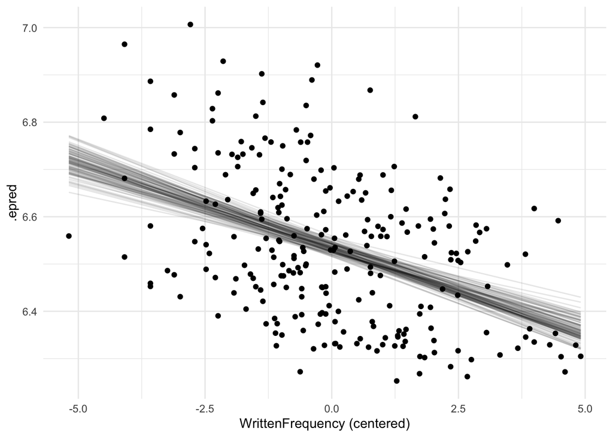

```r
## get grid of values on x axis
english_250 %>%
  data_grid(WrittenFrequency_c = seq_range(WrittenFrequency_c, n = 101)) %>%
  add_epred_draws(english_m42, ndraws = 100) %>%
  ggplot(aes(x = WrittenFrequency_c, y = RTlexdec)) +
  geom_line(aes(y = .epred, group = .draw), alpha = .1) +
  geom_point(data = english_250) +
  xlab("WrittenFrequency (centered)") +
  theme(legend.position = "none")
```

**Практически полезное замечание** При условии, что вы стандартизировали предикторы (включая использование схемы «центрированного» контрастного кодирования для факторов), `brms`, как правило, по умолчанию подбирает разумные «слабо информативные» прайоры. Это служит еще одной важной причиной для стандартизации данных перед построением моделей. (В настоящее время при работе с `brms` или `Stan` широко распространена практика использования прайоров «по умолчанию», хотя это и не рекомендуется: всегда полезно тщательно обдумать выбор априорных распределений.)

**Вопросы**

1. Почему на гексагональной диаграмме апостериорных распределений α и β₁ для модели `english_m41` наблюдается отрицательная зависимость между α и β₁?

(Подсказка: посмотрите на линии на диаграмме «спагетти» выше и подумайте, что означают α и β₁ для каждой линии графически.)

2. Постройте ту же диаграмму для модели `english_m42` и убедитесь, что апостериорные распределения для α и β₁ теперь выглядят независимыми. Почему это имеет смысл после того, как x₁ был центрирован? (Подсказка: α теперь является значением `RTlexdec`, при WrittenFrequency_c=0.)

## Множественная линейная регрессия

Построение регрессии с несколькими предикторами осуществляется аналогичным образом. Рассмотрим переменные `AgeSubject` и `WrittenFrequency` в качестве предикторов переменной `RTlexdec` для `english_250`.

Наблюдаемая связь выглядит следующим образом:

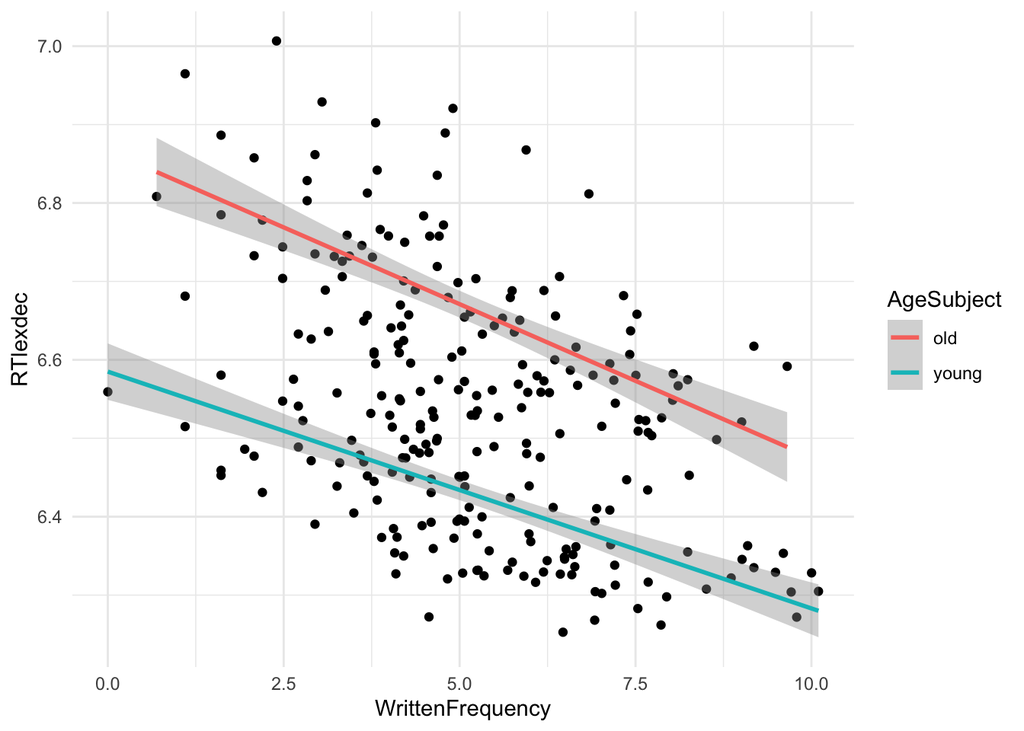

```r
english_250 %>% ggplot(aes(x = WrittenFrequency, y = RTlexdec)) +
  geom_point() +
  geom_smooth(method = "lm", aes(color = AgeSubject))
```

Используя ту же схему, что и выше:

```r
english_250 <- english_250 %>% mutate(
  SubjectYoung = as.numeric(AgeSubject)-1.5
)
```

```r
english_m43 <-
  brm(
    data = english_250,
    RTlexdec ~ 1 + WrittenFrequency_c + SubjectYoung,
    family = gaussian,
    prior = c(
      prior(normal(0, 100), class = Intercept),
      prior(normal(0, 5), class = b),
      prior(exponential(1), class = sigma)
    ),
    file = "models/english_m43.brm"
  )
```

Изучим вывод модели:

```r
english_m43
```

```
##  Family: gaussian
##   Links: mu = identity
## Formula: RTlexdec ~ 1 + WrittenFrequency_c + SubjectYoung
##    Data: english_250 (Number of observations: 250)
##   Draws: 4 chains, each with iter = 2000; warmup = 1000; thin = 1;
##          total post-warmup draws = 4000
##
## Regression Coefficients:
##                    Estimate Est.Error l-95% CI u-95% CI Rhat Bulk_ESS Tail_ESS
## Intercept              6.55      0.01     6.54     6.56 1.00     3792     3027
## WrittenFrequency_c    -0.03      0.00    -0.04    -0.03 1.00     5948     3728
## SubjectYoung          -0.24      0.01    -0.26    -0.21 1.00     3763     2451
##
## Further Distributional Parameters:
##       Estimate Est.Error l-95% CI u-95% CI Rhat Bulk_ESS Tail_ESS
## sigma     0.08      0.00     0.08     0.09 1.00     2970     2764
##
## Draws were sampled using sampling(NUTS). For each parameter, Bulk_ESS
## and Tail_ESS are effective sample size measures, and Rhat is the potential
## scale reduction factor on split chains (at convergence, Rhat = 1).
```

Обратите внимание, что `class = b` позволяет применять прайор ко всем коэффициентам β (β₁, β₂, …).

График-«спагетти» предсказываемой зависимости:

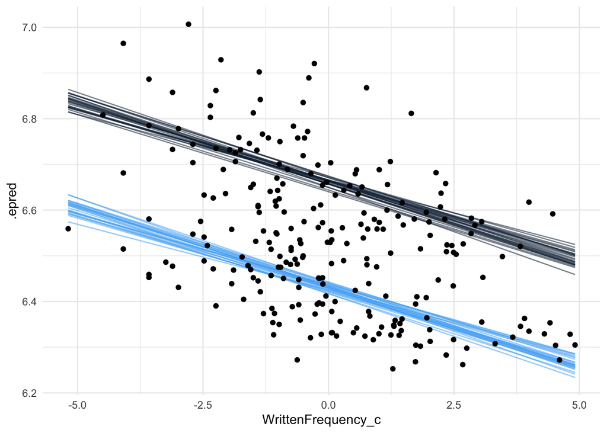

```r
english_250 %>%
  group_by(SubjectYoung) %>%
  data_grid(WrittenFrequency_c = seq_range(WrittenFrequency_c, n = 101), SubjectYoung = c(-0.5, 0.5)) %>%
  ## changed to 25 lines instead of 100 to
  ## make the graph more legible
  add_epred_draws(english_m43, ndraws = 25) %>%
  ggplot(aes(x = WrittenFrequency_c, y = RTlexdec)) +
  geom_line(aes(y = .epred, group = paste(SubjectYoung, .draw), color = SubjectYoung, alpha = .1)) +
  geom_point(data = english_250) +
  theme(legend.position = "none")
```

**Упражнение**  
Постройте график, отображающий PI (по аналогии с графиком для модели `english_m41`, приведенному выше).

## Маржинальные эффекты

В моделях множественной регрессии часто/обычно представляет интерес визуализация эффекта от варьирования одного или нескольких предикторов при сохранении остальных неизменными (например, на уровне 0 или среднего значения). Эти эффекты обычно называют *маржинальными эффектами* (marginal effects) или *условными эффектами* (conditional effects) — либо *частичными эффектами* (partial effects, хотя этот термин менее точен). МакЭлрит (2023) называет их «контрфактическими графиками» (counterfactual plots) — это более описательное и обобщенное название, хотя и нестандартное.

Как и всегда, вы можете воспользоваться готовыми функциями для расчета маржинальных эффектов или же выполнить прогнозирование самостоятельно. Одним из готовых инструментов является функция `conditional_effects()` из пакета `brms`. Мы используем ее для построения графика частичного эффекта для переменной `WrittenFrequency_c`:

```r
conditional_effects(english_m43, effects = "WrittenFrequency_c")
```

```
## Ignoring unknown labels:
## • fill : "NA"
## • colour : "NA"
## Ignoring unknown labels:
## • fill : "NA"
## • colour : "NA"
```

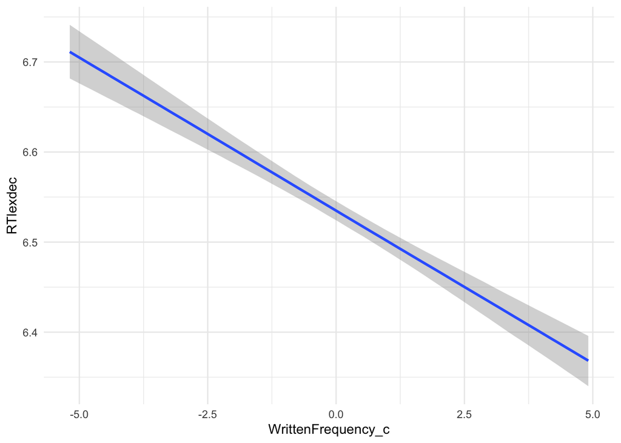

Эту функцию можно настроить так, чтобы она возвращала датафрейм…

```r
conditional_effects(english_m43, effects = "WrittenFrequency_c")$WrittenFrequency_c -> freqPartial_df
head(freqPartial_df) ## lower/upper/estimate = 95% CredI + mean of posterior
```

```
##   WrittenFrequency_c RTlexdec SubjectYoung cond__ effect1__ estimate__
## 1          -5.187430 6.534968        0.048      1 -5.187430   6.711233
## 2          -5.085406 6.534968        0.048      1 -5.085406   6.707733
## 3          -4.983382 6.534968        0.048      1 -4.983382   6.704298
## 4          -4.881357 6.534968        0.048      1 -4.881357   6.700802
## 5          -4.779333 6.534968        0.048      1 -4.779333   6.697317
## 6          -4.677308 6.534968        0.048      1 -4.677308   6.693864
##         se__  lower__  upper__
## 1 0.01529500 6.681701 6.741258
## 2 0.01505150 6.678707 6.737294
## 3 0.01478055 6.675702 6.733359
## 4 0.01453273 6.672726 6.729392
## 5 0.01423833 6.669802 6.725534
## 6 0.01392309 6.666801 6.721585
```

… который можно будет использовать для создания более качественных визуализаций:

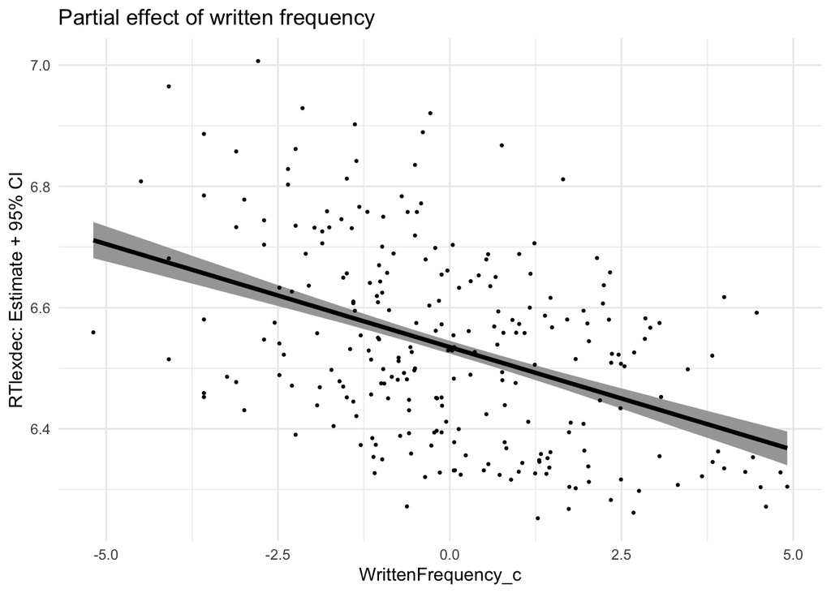

```r
freqPartial_df %>% ggplot(aes(x = WrittenFrequency_c, y = estimate__)) +
  geom_lineribbon(aes(ymin = lower__, ymax = upper__)) +
  geom_point(aes(x = WrittenFrequency_c, y = RTlexdec), data = english_250, size = 0.5) +
  ylab("RTlexdec") +
  ggtitle("Partial effect of written frequency") +
  ylab("RTlexdec: Estimate + 95% CI")
```

Пример построения собственного графика маржинального эффекта для переменной `AgeSubject` с интервалами прогнозирования:

```r
## Make a dataframe of values to predict at: vary SubjectYoung hold WrittenFrequency_c at 0
agePartial_df <- expand_grid(SubjectYoung = c(-0.5, 0.5), WrittenFrequency_c = 0)
agePartial_df
```

```
## # A tibble: 2 × 2
##   SubjectYoung WrittenFrequency_c
##          <dbl>              <dbl>
## 1         -0.5                  0
## 2          0.5                  0
```

```r
## # A tibble: 2 × 2
##   SubjectYoung WrittenFrequency_c
##          <dbl>              <dbl>
## 1         -0.5                  0
## 2          0.5                  0

## for 95% CIs, we'd use 'fitted' instead of 'predict' here.
predict(english_m43, newdata = agePartial_df) -> fittedVals
fittedVals
```

```
##      Estimate  Est.Error     Q2.5    Q97.5
## [1,] 6.662423 0.08556956 6.496872 6.836341
## [2,] 6.429005 0.08427800 6.265710 6.596410
```

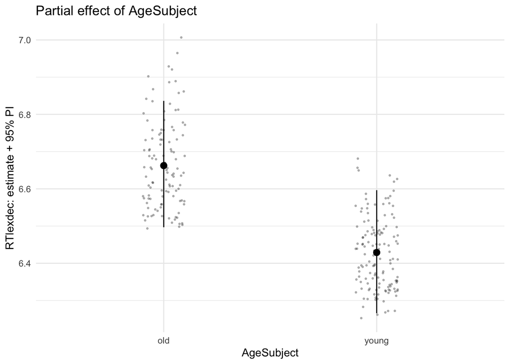

```r
##      Estimate  Est.Error     Q2.5    Q97.5
## [1,] 6.667137 0.08236155 6.501877 6.826921
## [2,] 6.429246 0.08451450 6.259287 6.593990

agePartial_df <- bind_cols(agePartial_df, data.frame(fittedVals))

## add back AgeSubject for plotting
agePartial_df <- agePartial_df %>% mutate(AgeSubject = factor(SubjectYoung, labels = levels(english_250$AgeSubject)))


agePartial_df %>% ggplot(aes(x = AgeSubject, y = Estimate)) +
  geom_pointrange(aes(ymin = Q2.5, ymax = Q97.5)) +
  geom_jitter(aes(x = AgeSubject, y = RTlexdec), data = english_250, size = 0.5, width = 0.1, alpha = 0.25) +
  ggtitle("Partial effect of AgeSubject") +
  ylab("RTlexdec: estimate + 95% PI")
```

**Упражнение**  
Постройте график, отображающий апостериорное распределение разности предсказанных значений `RTlexdec` для групп `AgeSubject`=`old` и `young` при фиксированном значении `WrittenFrequency_c`, равном 0. График должен напоминать диаграмму типа half-eye.

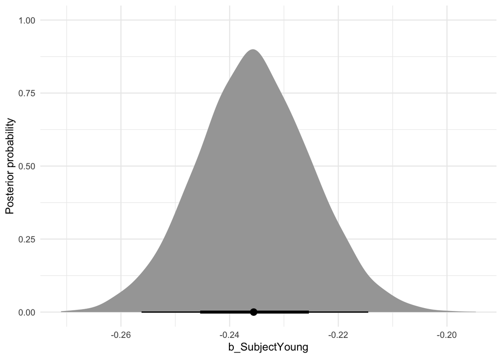

```r
english_m43 %>% spread_draws(b_SubjectYoung) %>%
  ggplot(aes(x = b_SubjectYoung)) +
    stat_halfeye()+
    xlab("b_SubjectYoung")+
    ylab("Posterior probability")
```

## Нелинейные эффекты

При построении графика с использованием сглаживающей функции вместо регрессионной прямой создается впечатление, что зависимость `RTlexdec` и `WrittenFrequency_c` может быть нелинейной:

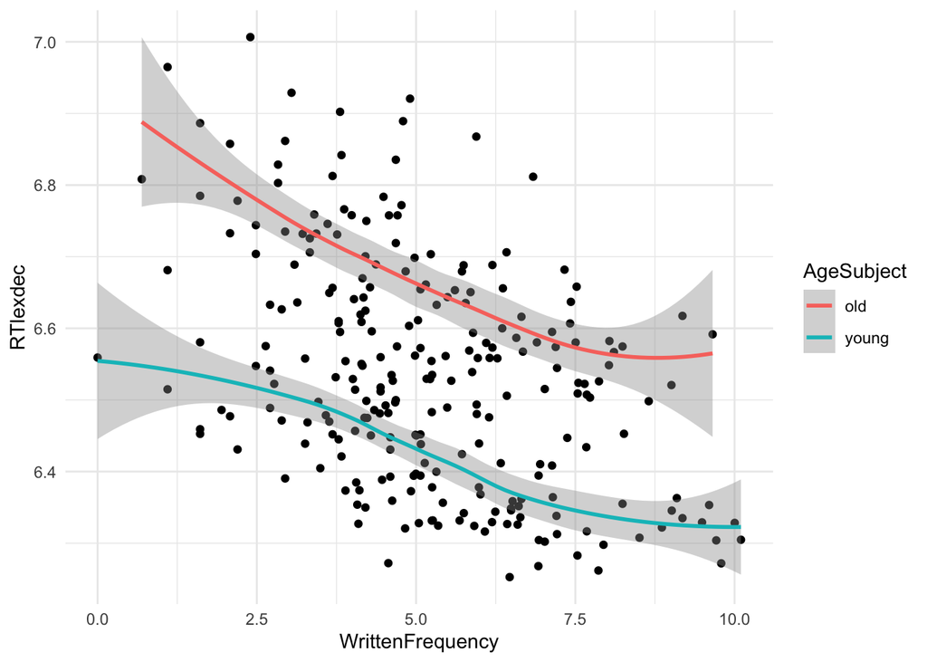

```r
english_250 %>% ggplot(aes(x = WrittenFrequency, y = RTlexdec)) +
  geom_point() +
  geom_smooth(method = "loess", aes(color = AgeSubject))
```

Самый простой способ аппроксимировать нелинейную функцию — использовать полиномы. Мы будем использовать ортогональные полиномы, реализованные с помощью функции `poly()`.

Для полинома 3-го порядка (чтобы смоделировать две точки перегиба, заметные на графике `AgeSubject`):

```r
english_m44 <-
  brm(
    data = english_250,
    RTlexdec ~ 1 + poly(WrittenFrequency_c, 3) + SubjectYoung,
    family = gaussian,
    prior = c(
      prior(normal(0, 100), class = Intercept),
      prior(normal(0, 5), class = b),
      prior(exponential(1), class = sigma)
    ),
    file = "models/english_m44.brm"
  )
```

```r
english_m44
```

```
##  Family: gaussian
##   Links: mu = identity
## Formula: RTlexdec ~ 1 + poly(WrittenFrequency_c, 3) + SubjectYoung
##    Data: english_250 (Number of observations: 250)
##   Draws: 4 chains, each with iter = 2000; warmup = 1000; thin = 1;
##          total post-warmup draws = 4000
##
## Regression Coefficients:
##                          Estimate Est.Error l-95% CI u-95% CI Rhat Bulk_ESS
## Intercept                    6.55      0.01     6.54     6.56 1.00     5569
## polyWrittenFrequency_c31    -1.05      0.08    -1.21    -0.88 1.00     6804
## polyWrittenFrequency_c32     0.15      0.08    -0.01     0.31 1.00     5765
## polyWrittenFrequency_c33     0.14      0.08    -0.03     0.31 1.00     5724
## SubjectYoung                -0.24      0.01    -0.26    -0.22 1.00     5461
##                          Tail_ESS
## Intercept                    2990
## polyWrittenFrequency_c31     2967
## polyWrittenFrequency_c32     3031
## polyWrittenFrequency_c33     3240
## SubjectYoung                 2969
##
## Further Distributional Parameters:
##       Estimate Est.Error l-95% CI u-95% CI Rhat Bulk_ESS Tail_ESS
## sigma     0.08      0.00     0.08     0.09 1.00     5572     2830
##
## Draws were sampled using sampling(NUTS). For each parameter, Bulk_ESS
## and Tail_ESS are effective sample size measures, and Rhat is the potential
## scale reduction factor on split chains (at convergence, Rhat = 1).
```

Коэффициенты в данном случае не поддаются простой интерпретации. Как правило, мы интерпретируем нелинейные эффекты, анализируя модельные предсказания. Построим график-спагетти для подобранных значений (а не график маржинального эффекта для переменной `WrittenFrequency_c`):

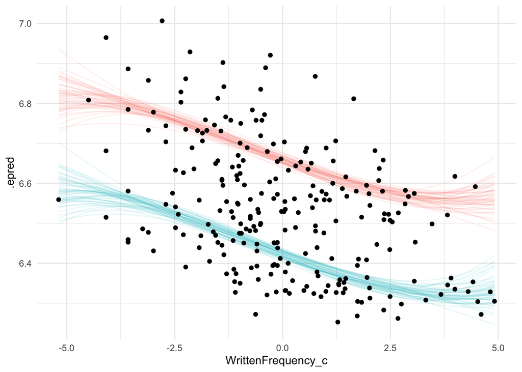

```r
english_250 %>%
  data_grid(WrittenFrequency_c = seq_range(WrittenFrequency_c, n = 101), SubjectYoung = c(-0.5, 0.5)) %>%
  add_epred_draws(english_m44, ndraws = 50) %>%
  ggplot(aes(x = WrittenFrequency_c, y = RTlexdec)) +
  ## the factor() stuff is just to get SubjectYoung = -0.5, 0.5 to appear as blue/red in graph
  geom_line(aes(y = .epred, group = paste(factor(SubjectYoung), .draw), color = factor(SubjectYoung)), alpha = .1) +
  geom_point(data = english_250) +
  theme(legend.position = "none")
```

Обратите внимание, насколько более неопределенным становится эффект вблизи верхней и нижней границ предиктора (`WrittenFrequency_c`). Это явление хорошо знакомо по полиномиальным эффектам во фреквентистских моделях (где доверительные интервалы расширяются ближе к границам), однако байесовская модель позволяет гораздо яснее понять суть происходящего: данному набору данных соответствуют множество полиномов, различающихся лишь на крайних участках. Стремление избежать подобных подгонок служит одной из главных причин для использования сплайнов в обобщенных аддитивных моделях (GAM).

**Упражнение** Постройте график маржинального эффекта для переменной `WrittenFrequency_c` в модели `english_m44` с 95%-ыми CI.

### Мультиколлинеарность: пример

Корреляции между предикторами (точнее — между эффектами предикторов после учета влияния остальных), или **мультиколлинеарность**, представляют собой важную проблему, которую необходимо принимать во внимание при построении любых регрессионных моделей. В контексте байесовских регрессионных моделей пример с использованием сильно коррелирующих предикторов поможет нам понять, какой смысл имеют коэффициенты построенной байесовской модели.

В наборе данных `english` переменные `WrittenFrequency` и `Familiarity` сильно коррелируют друг с другом, но при этом оба отрицательно коррелируют с `RTlexdec`. В частности, в подвыборке `english_25`:

```r
english_25 <- english[sample(1:nrow(english), 25), ]
cor(dplyr::select(english_25, RTlexdec, WrittenFrequency, Familiarity))
```

```
##                    RTlexdec WrittenFrequency Familiarity
## RTlexdec          1.0000000       -0.2845673  -0.2773240
## WrittenFrequency -0.2845673        1.0000000   0.7877556
## Familiarity      -0.2773240        0.7877556   1.0000000
```

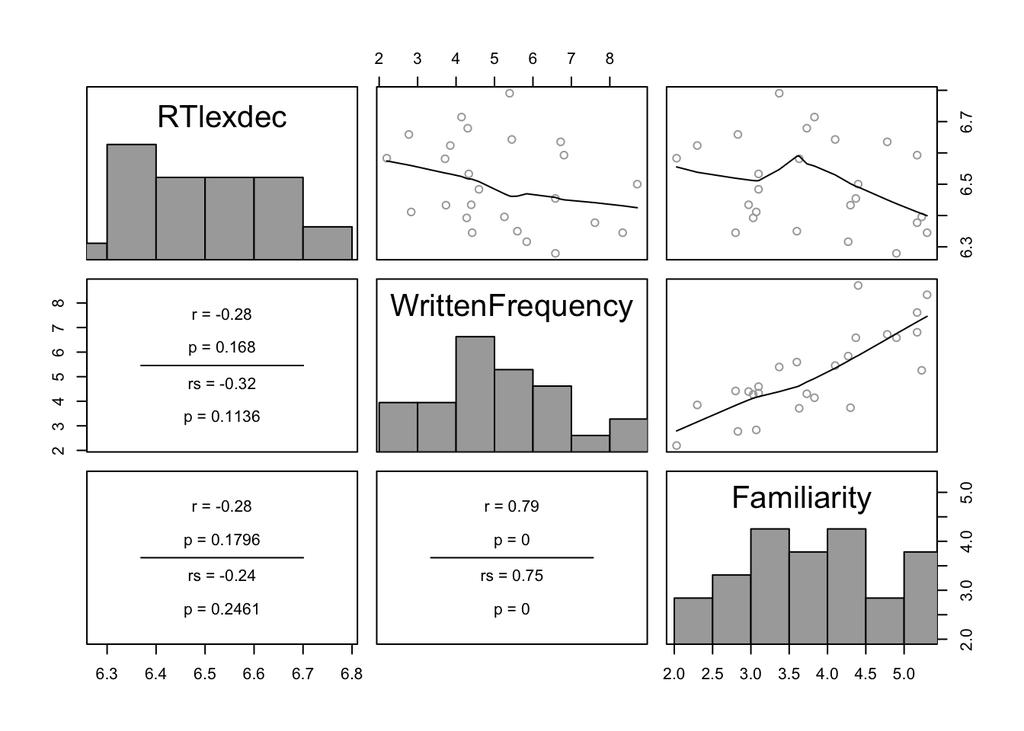

```r
##                    RTlexdec WrittenFrequency Familiarity
## RTlexdec          1.0000000       -0.4016724  -0.5791578
## WrittenFrequency -0.4016724        1.0000000   0.8313906
## Familiarity      -0.5791578        0.8313906   1.0000000

pairscor.fnc(dplyr::select(english_25, RTlexdec, WrittenFrequency, Familiarity))
```

Построим модель линейной регрессии для `english_25` с центрирование предикторов:

- *y*: `RTlexdec`
- $x_1$, $x_2$, $x_3$: `WrittenFrequency_c`, `SubjectYoung`, `Familiarity_c`
- Априорные распределения — те же, что и для моделей выше.

```r
# center predictors
english_25 <- mutate(english_25,
  WrittenFrequency_c = scale(WrittenFrequency, scale = FALSE),
  Familiarity_c = scale(Familiarity, scale = FALSE),
  SubjectYoung = as.numeric(AgeSubject) - 1.5
)
```

```r
english_collin_m1 <-
  brm(
    data = english_25,
    RTlexdec ~ 1 + WrittenFrequency_c + Familiarity_c + SubjectYoung,
    family = gaussian,
    prior = c(
      prior(normal(0, 100), class = Intercept),
      prior(normal(0, 5), class = b),
      prior(exponential(1), class = sigma)
    ),
    file = "models/english_collin_m1.brm"
  )
```

```r
english_collin_m1
```

```
##  Family: gaussian
##   Links: mu = identity
## Formula: RTlexdec ~ 1 + WrittenFrequency_c + Familiarity_c + SubjectYoung
##    Data: english_25 (Number of observations: 25)
##   Draws: 4 chains, each with iter = 2000; warmup = 1000; thin = 1;
##          total post-warmup draws = 4000
##
## Regression Coefficients:
##                    Estimate Est.Error l-95% CI u-95% CI Rhat Bulk_ESS Tail_ESS
## Intercept              6.59      0.02     6.54     6.63 1.00     2811     1902
## WrittenFrequency_c    -0.01      0.03    -0.06     0.05 1.00     1962     2113
## Familiarity_c         -0.02      0.04    -0.11     0.06 1.00     1971     2279
## SubjectYoung          -0.27      0.05    -0.36    -0.18 1.00     3094     2709
##
## Further Distributional Parameters:
##       Estimate Est.Error l-95% CI u-95% CI Rhat Bulk_ESS Tail_ESS
## sigma     0.11      0.02     0.08     0.15 1.00     2586     2275
##
## Draws were sampled using sampling(NUTS). For each parameter, Bulk_ESS
## and Tail_ESS are effective sample size measures, and Rhat is the potential
## scale reduction factor on split chains (at convergence, Rhat = 1).
```

Визуализируем совместное апостериорное распределение для $\beta_1$ и $\beta_3$:

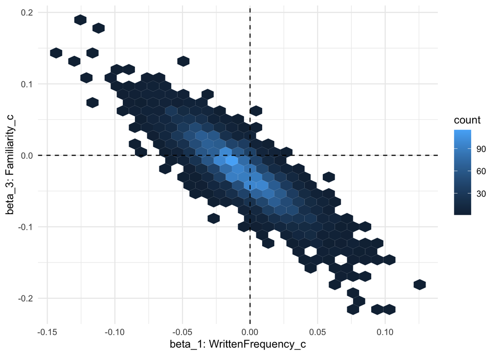

```r
# heatmap of posterior for two coefficients, with lines at beta_1, beta_3 = 0
english_collin_m1 %>%
  spread_draws(b_WrittenFrequency_c, b_Familiarity_c) %>%
  ggplot(aes(x = b_WrittenFrequency_c, y = b_Familiarity_c)) +
  geom_hex() +
  xlab("beta_1: WrittenFrequency_c") +
  ylab("beta_3: Familiarity_c") +
  geom_vline(aes(xintercept = 0), lty = 2) +
  geom_hline(aes(yintercept = 0), lty = 2)
```

Визуализируем *маржинальные* постериоры для $\beta_1$ и $\beta_3$:

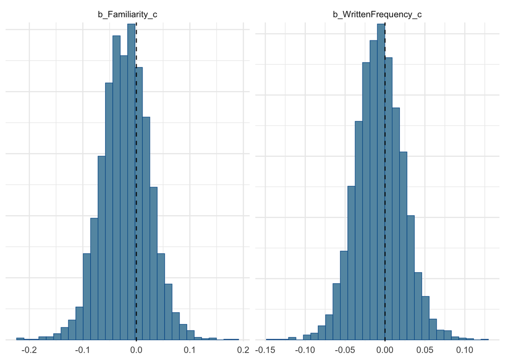

```r
# dotted line: 0
mcmc_plot(english_collin_m1, type = "hist", variable = c("b_Familiarity_c", "b_WrittenFrequency_c")) + geom_vline(aes(xintercept = 0), lty = 2)
```

Тот факт, что эти интервалы перекрывают 0, соответствует перекрывающимся 95%-ым CredI для `WrittenFrequency_c` и `Familiarity_c` в приведенной выше таблице модели.

## Множественная регрессия для GLM: логистическая регрессия

Начнем с фреквентистской модели:

```r
diatones <- read.csv("https://osf.io/tqjm8/download")
glm(stress_shifted ~ syll2_coda + syll2_td + frequency + syll1_coda,
  data = diatones, family = "binomial"
) %>% tidy(conf.int = TRUE)
```

[output not shown]

```
## # A tibble: 7 × 7
##   term          estimate std.error statistic p.value conf.low conf.high
##   <chr>            <dbl>     <dbl>     <dbl>   <dbl>    <dbl>     <dbl>
## 1 (Intercept)     -0.197     0.753   -0.262   0.793    -1.76     1.25
## 2 syll2_codaC     -1.72      0.770   -2.24    0.0254   -3.24    -0.159
## 3 syll2_codaCC    -2.15      1.01    -2.13    0.0334   -4.22    -0.200
## 4 syll2_codaCCC  -17.5    1557.      -0.0112  0.991    NA      224.
## 5 syll2_tdyes      0.828     0.597    1.39    0.165    -0.342    2.03
## 6 frequency       -0.189     0.140   -1.34    0.179    -0.467    0.0903
## 7 syll1_codayes    1.36      0.565    2.41    0.0159    0.246    2.49
```

```r
#glm(stress_shifted ~ syll2_coda + syll1_coda,
#  data = diatones, family = "binomial"
#) %>% tidy(conf.int = TRUE)
```

Теперь построим байесовскую логистическую регрессию с помощью `brms`:

```r
diatones_m41 <- brm(
  data = diatones,
  stress_shifted | trials(1) ~ syll2_coda + syll2_td + frequency + syll1_coda,
  family = binomial,
  prior = c(
    prior(normal(0, 5), class = Intercept),
    prior(normal(0, 3), class = b)
  ),
  file = "models/diatones_m41.brm"
)
```

```r
diatones_m41
```

```
##  Family: binomial
##   Links: mu = logit
## Formula: stress_shifted | trials(1) ~ syll2_coda + syll2_td + frequency + syll1_coda
##    Data: diatones (Number of observations: 130)
##   Draws: 4 chains, each with iter = 2000; warmup = 1000; thin = 1;
##          total post-warmup draws = 4000
##
## Regression Coefficients:
##               Estimate Est.Error l-95% CI u-95% CI Rhat Bulk_ESS Tail_ESS
## Intercept        -0.54      0.76    -2.06     0.90 1.00     3622     2759
## syll2_codaC      -1.34      0.74    -2.74     0.15 1.00     2219     2513
## syll2_codaCC     -1.70      0.94    -3.62     0.13 1.00     2012     2337
## syll2_codaCCC    -2.88      2.06    -7.20     0.83 1.00     3740     3061
## syll2_tdyes       0.63      0.57    -0.49     1.75 1.00     3478     3103
## frequency        -0.19      0.14    -0.46     0.09 1.00     4091     2888
## syll1_codayes     1.25      0.57     0.15     2.36 1.00     3642     3226
##
## Draws were sampled using sampling(NUTS). For each parameter, Bulk_ESS
## and Tail_ESS are effective sample size measures, and Rhat is the potential
## scale reduction factor on split chains (at convergence, Rhat = 1).
```

## Проверка прогностической способности прайоров

В качестве примера моделирования априорной прогностической способности давайте выберем выборку только из априорного распределения для модели english_m43, используя априорное прогностическое распределение. Для этого нам нужно изменить вызов brm() следующим образом:

- Использовать `sample_prior = 'only'`
- Увеличить количество выборок (2000 $\rightarrow$ 20000), поскольку выборка из априорного распределения может занять больше времени, так как оно гораздо более размыто, чем апостериорное.

```r
english_m43_prior <-
  brm(
    data = english_250,
    RTlexdec ~ 1 + WrittenFrequency_c + SubjectYoung,
    family = gaussian, sample_prior = "only",
    iter = 20000,
    prior = c(
      prior(normal(0, 10), class = Intercept),
      prior(normal(0, 5), class = b),
      prior(exponential(1), class = sigma)
    ),
    file = "models/english_m43_prior.brm.rds"
  )
```

Изучим маржинальный эффект `WrittenFrequency_c`:

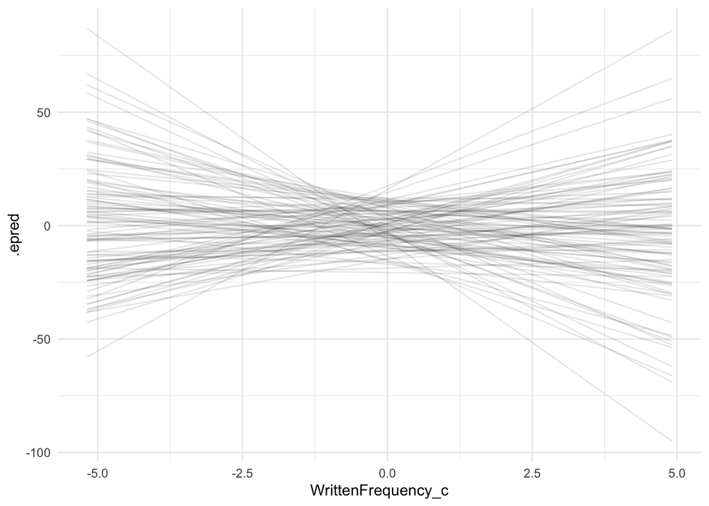

```r
english_250 %>%
  group_by(SubjectYoung) %>%
  data_grid(WrittenFrequency_c = seq_range(WrittenFrequency_c, n = 101), SubjectYoung = 0) %>%
  add_epred_draws(english_m43_prior, ndraws = 100) %>%
  ggplot(aes(x = WrittenFrequency_c, y = RTlexdec)) +
  geom_line(aes(y = .epred, group = .draw), alpha = .1)
```

Обратите внимание на использование функции data_grid() для создания датафрейма значений предикторов.

Рассмотрим случай изменения одного предиктора (WrittenFrequency) при сохранении другого постоянным (AgeSubject).

Линии на графике показывают, какие эффекты `WrittenFrequency_c` модель считает возможными до получения каких-либо данных — это состояние предварительных знаний. Знания предметной области говорят нам, что это безумные прогнозы. Простое нажатие кнопки занимает у человека как минимум ~175 мс, поэтому 150 мс — это разумное минимальное значение для прогнозируемого времени реакции; это `RTlexdec` = 5 (log(150)=5,01). Решения, принимаемые дольше нескольких секунд, означают, что что-то не так; давайте возьмем `RTledec = 8` в качестве максимального значения для прогнозируемого времени реакции (= 3 секунды). Перестроим график выше с этими границами:

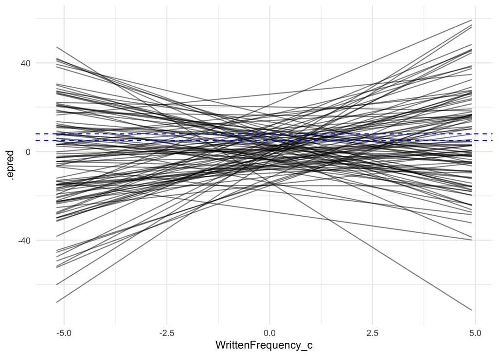

```r
english_250 %>%
  group_by(SubjectYoung) %>%
  data_grid(WrittenFrequency_c = seq_range(WrittenFrequency_c, n = 101), SubjectYoung = 0) %>%
  add_epred_draws(english_m43_prior, ndraws = 100) %>%
  ggplot(aes(x = WrittenFrequency_c, y = RTlexdec)) +
  geom_line(aes(y = .epred, group = .draw), alpha = .5) +
  geom_hline(aes(yintercept = 5), lty = 2, color = "blue") +
  geom_hline(aes(yintercept = 8), lty = 2, color = "blue")
```

Как мы можем добиться лучших результатов? Как мы объяснили при подгонке исходной модели:

Разумные значения `RTlexdec` находятся в диапазоне [5, 8], поэтому мы могли бы выбрать априорное распределение для свободного члена, которое имеет наибольшую вероятность в этом диапазоне, т.е. нормальное распределение с учетом ±3$\sigma$:
$$\alpha \sim N(6.5, 0.5)$$
Наклон для `WrittenFrequency_c`, равный -0,1, был бы огромным; для `SubjectYoung` наклон, равный -2, был бы огромным. Мы могли бы принять эти значения равными 2 $\sigma$ от среднего значения прайоров для $\beta_1$ и $\beta_2$. Кроме того, мы были бы очень удивлены, если бы какой-либо из эффектов не был отрицательным (у более молодых носителей языка и для более часто употребляемых слов время реакции короче), поэтому давайте сделаем средние значения априорного распределения отрицательными.

$$\beta_1 \sim N(-0.05, 0.025)$$
$$\beta_2 \sim N(-0.5, 0.75)$$

```r
english_m45_prior <-
  brm(
    data = english_250,
    RTlexdec ~ 1 + WrittenFrequency_c + SubjectYoung,
    family = gaussian, sample_prior = "only",
    iter = 20000,
    prior = c(
      prior(normal(6.5, 0.5), class = Intercept),
      prior(normal(-0.05, 0.025 ), class = b, coef = WrittenFrequency_c),
      prior(normal(-0.5, 0.75), class = b, coef = SubjectYoung),
      prior(exponential(1), class = sigma)
    ),
    file = "models/english_m45_prior.brm"
  )
```

Теперь выглядит больше похожим на правду. Возможно, нам даже стоит сделать прайоры (может быть, для наклона?) немного менее информативными.